# ex_1

Ćwiczenia nr 1 - rozkład stóp zwrotu Wprowadzenie

Dla danych z lat 2015-2025 ściągnąć dzienne, tygodniowe i miesięczne kursy zamknięcia wybranej spółki (indeksu) giełdowego. Jeśli masz problemy z tym działaniem, możesz wykorzystać dane załączone do kursu).

Następnie zdefiniować proste i logarytmiczne stopy zwrotu (poniżej mamy wzory):

stopy proste dane są wzorem Z(t) = 100 * (X(t) - X(t-1))/X(t-1) stopy logarytmiczne dane wzorem Z(t) = 100 * ln (X(t)/X(t-1)) Jak się okazuje, oba podejścia do liczenia zmian cen walorów mają swoje zalety i wady. O ile znajomość stóp prostych w najbardziej naturalny sposób oddaje informację o tym, jak zmienia się cena danego waloru, to lepsze własności matematyczne mają stopy logarytmiczne.

Zadanie do samodzielnego wykonania:

Na wykresie przedstawić dzienne/tygodniowe/miesięczne notowania wybranej spółki (indeksu) Dla najnowszych danych (trzy lata) wyznaczyć dzienne i tygodniowe logarytmiczne i proste stopy zwrotu. Dla danych z ostatnich 10 lat wyznaczyć logarytmiczne i proste miesięczne stopy zwrotu. Dla danych dziennych z lat 2022-2024 oraz miesięcznych z lat 2007-2024, narysować wykres obu typów stóp zwrotu oraz wykres różnicy między stopą prostą i logarytmiczną. Jakie wnioski wynikają z obserwacji (proszę o 1-2 zdania wyjaśnienia)?

```python
from pathlib import Path
import pandas as pd
import matplotlib.pyplot as plt
import numpy as np
```

```python
CSV_PATH = Path('spx_d.csv')

data_frame_daily: pd.DataFrame = pd.read_csv(
        CSV_PATH,
        # usecols=['datetime', 'open', 'high', 'low', 'close'],
        usecols=['Data','Otwarcie','Najwyzszy','Najnizszy','Zamkniecie','Wolumen'],
        parse_dates=['Data']
    )
data_frame_daily.set_index('Data').sort_index().astype('float64')

# konwersja kolumny 'Data' na datetime, bo bez tego są błedne daty
data_frame_daily['Data'] = pd.to_datetime(data_frame_daily['Data'], errors='coerce')

# usuwam ewentualne błędne wiersze bez dat
data_frame_daily = data_frame_daily.dropna(subset=['Data'])

# indeks i sortuje
data_frame_daily = (
    data_frame_daily
    .set_index('Data')
    .sort_index()
    .astype('float64')
)
print(data_frame_daily.head(10))

data_frame_weekly = data_frame_daily.resample('W-FRI').agg({
    'Otwarcie': 'first',
    'Najwyzszy': 'max',
    'Najnizszy': 'min',
    'Zamkniecie': 'last',
    'Wolumen': 'sum'
}).dropna()
print(data_frame_weekly.head(10))

data_frame_monthly = data_frame_daily.resample('ME').agg({
    'Otwarcie': 'first',
    'Najwyzszy': 'max',
    'Najnizszy': 'min',
    'Zamkniecie': 'last',
    'Wolumen': 'sum'
}).dropna()
print(data_frame_monthly.head(10))
```

```
            Otwarcie  Najwyzszy  Najnizszy  Zamkniecie       Wolumen
Data
2015-01-02   2058.90    2072.36    2046.04     2058.20  1.504833e+09
2015-01-05   2054.44    2054.44    2017.34     2020.58  2.110622e+09
2015-01-06   2022.15    2030.25    1992.44     2002.61  2.477839e+09
2015-01-07   2005.55    2029.61    2005.55     2025.90  2.114156e+09
2015-01-08   2030.61    2064.08    2030.61     2062.14  2.185561e+09
2015-01-09   2063.45    2064.43    2038.33     2044.81  1.868967e+09
2015-01-12   2046.13    2049.30    2022.58     2028.26  1.920256e+09
2015-01-13   2031.58    2056.93    2008.25     2023.03  2.281833e+09
2015-01-14   2018.40    2018.40    1988.44     2011.27  2.432600e+09
2015-01-15   2013.75    2021.35    1991.47     1992.67  2.375956e+09
            Otwarcie  Najwyzszy  Najnizszy  Zamkniecie       Wolumen
Data
2015-01-02   2058.90    2072.36    2046.04     2058.20  1.504833e+09
2015-01-09   2054.44    2064.43    1992.44     2044.81  1.075714e+10
2015-01-16   2046.13    2056.93    1988.12     2019.42  1.126421e+10
2015-01-23   2020.76    2064.62    2004.49     2051.82  8.568900e+09
2015-01-30   2050.42    2057.62    1989.18     1994.99  1.086605e+10
2015-02-06   1996.67    2072.40    1980.90     2055.47  1.156728e+10
2015-02-13   2053.47    2097.03    2041.88     2096.99  1.007336e+10
2015-02-20   2096.47    2110.61    2085.44     2110.30  7.366928e+09
2015-02-27   2109.83    2119.59    2103.00     2104.50  9.201072e+09
2015-03-06   2105.23    2117.52    2067.27     2071.26  9.471944e+09
            Otwarcie  Najwyzszy  Najnizszy  Zamkniecie       Wolumen
Data
2015-01-31   2058.90    2072.36    1988.12     1994.99  4.296113e+10
2015-02-28   1996.67    2119.59    1980.90     2104.50  3.820864e+10
2015-03-31   2105.23    2117.52    2039.69     2067.89  4.259769e+10
2015-04-30   2067.63    2125.92    2048.38     2085.51  4.003386e+10
2015-05-31   2087.38    2134.72    2067.93     2107.39  3.621541e+10
2015-06-30   2108.64    2129.87    2056.32     2063.11  4.067443e+10
2015-07-31   2067.00    2132.82    2044.02     2103.84  4.328922e+10
2015-08-31   2104.49    2112.66    1867.01     1972.18  4.701488e+10
2015-09-30   1970.09    2020.86    1871.91     1920.03  4.443854e+10
2015-10-31   1919.65    2094.32    1893.70     2079.36  4.769161e+10
```

# 1. Na wykresie przedstawić dzienne/tygodniowe/miesięczne notowania wybranej spółki (indeksu)

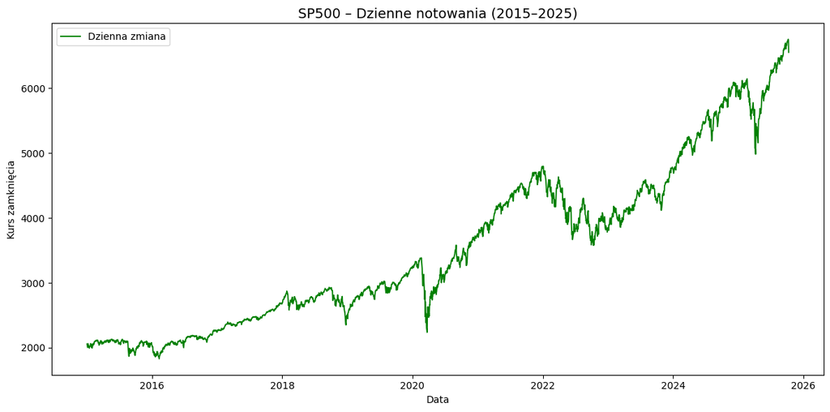

```python
fig, ax = plt.subplots(figsize=(12, 6))
ax.plot(
    data_frame_daily.index,
    data_frame_daily['Zamkniecie'],
    label='Dzienna zmiana',
    color='green',
    linewidth=1.3
)

ax.set_title('SP500 – Dzienne notowania (2015–2025)', fontsize=14)
ax.set_xlabel('Data')
ax.set_ylabel('Kurs zamknięcia')
ax.legend()
plt.tight_layout()
plt.show()
```

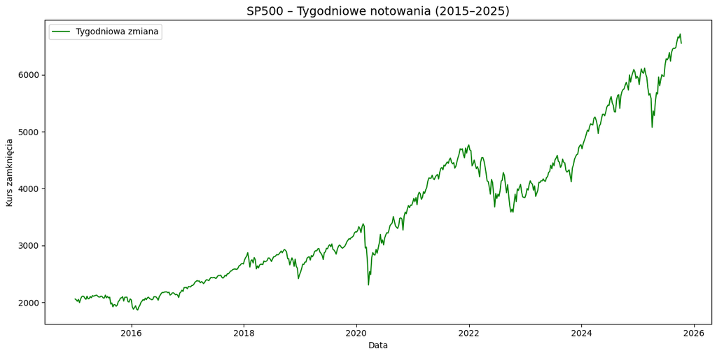

```python
fig, ax = plt.subplots(figsize=(12, 6))
ax.plot(
    data_frame_weekly.index,
    data_frame_weekly['Zamkniecie'],
    label='Tygodniowa zmiana',
    color='green',
    linewidth=1.3
)

ax.set_title('SP500 – Tygodniowe notowania (2015–2025)', fontsize=14)
ax.set_xlabel('Data')
ax.set_ylabel('Kurs zamknięcia')
ax.legend()
plt.tight_layout()
plt.show()
```

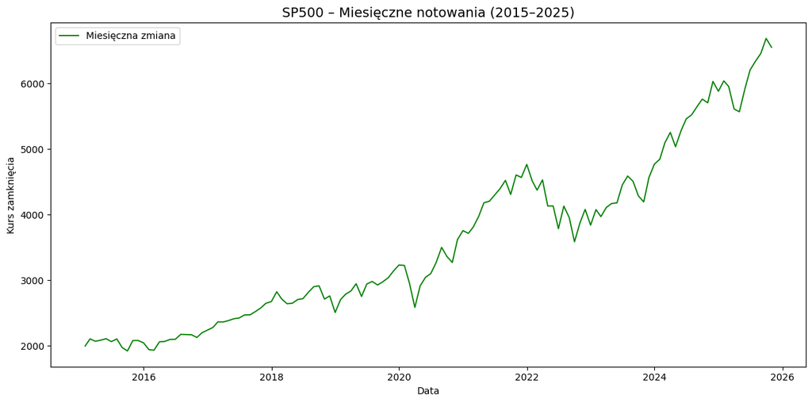

```python
fig, ax = plt.subplots(figsize=(12, 6))
ax.plot(
    data_frame_monthly.index,
    data_frame_monthly['Zamkniecie'],
    label='Miesięczna zmiana',
    color='green',
    linewidth=1.3
)

ax.set_title('SP500 – Miesięczne notowania (2015–2025)', fontsize=14)
ax.set_xlabel('Data')
ax.set_ylabel('Kurs zamknięcia')
ax.legend()
plt.tight_layout()
plt.show()
```

```python
# # Funkcja pomocznica do liczenia zwrotów
def compute_returns(series: pd.Series) -> pd.DataFrame:
    """
    Obliczam stopy zwrotu zgodnie ze wzorami:
    Z_prosta(t) = 100 * (X_t - X_{t-1}) / X_{t-1}
    Z_logarytmiczna(t) = 100 * ln(X_t / X_{t-1})
    """
    returns = pd.DataFrame(index=series.index)
    returns["Prosta"] = 100 * (series - series.shift(1)) / series.shift(1)
    returns["Logarytmiczna"] = 100 * np.log(series / series.shift(1))
    return returns

# Funkcja pomocnicza do rysowania wykresów zwrotów
def plot_returns(df: pd.DataFrame, title: str):
    fig, ax = plt.subplots(figsize=(12, 6))
    ax.plot(df.index, df["Prosta"], label="Stopa prosta")
    ax.plot(df.index, df["Logarytmiczna"], label="Stopa logarytmiczna")
    ax.set_title(title, fontsize=14)
    ax.set_xlabel("Data")
    ax.set_ylabel("Stopa zwrotu (%)")
    ax.legend()

    plt.tight_layout()
    plt.show()
```

# 2. Dla najnowszych danych (trzy lata) wyznaczyć dzienne i tygodniowe logarytmiczne i proste stopy zwrotu.

```
              Prosta  Logarytmiczna
Data
2025-09-29  0.263558       0.263211
2025-09-30  0.409085       0.408250
2025-10-01  0.339989       0.339412
2025-10-02  0.061837       0.061818
2025-10-03  0.006552       0.006552
2025-10-06  0.364663       0.364000
2025-10-07 -0.381141      -0.381870
2025-10-08  0.582761       0.581069
2025-10-09 -0.275552      -0.275932
2025-10-10 -2.711166      -2.748596
```

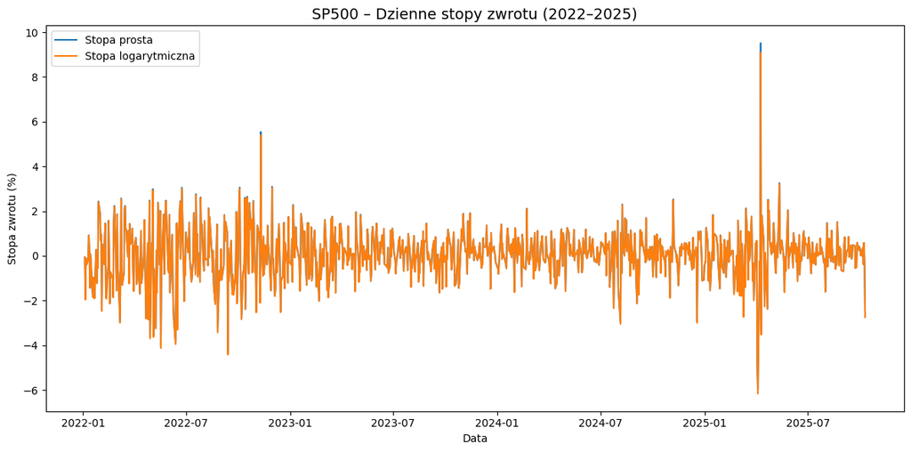

```python
# DZIENNE
data_recent_daily = data_frame_daily.loc['2022-01-01':]
returns_monthly = compute_returns(data_recent_daily["Zamkniecie"])
print(returns_monthly.tail(10))
plot_returns(returns_monthly, "SP500 – Dzienne stopy zwrotu (2022–2025)")
```

```
              Prosta  Logarytmiczna
Data
2025-08-08  2.427697       2.398697
2025-08-15  0.944526       0.940093
2025-08-22  0.265280       0.264928
2025-08-29 -0.102831      -0.102884
2025-09-05  0.328779       0.328240
2025-09-12  1.585898       1.573454
2025-09-19  1.216076       1.208742
2025-09-26 -0.310007      -0.310489
2025-10-03  1.085088       1.079243
2025-10-10 -2.431285      -2.461329
```

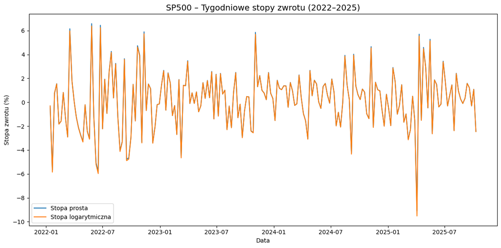

```python
# TYGODNIOWE
data_recent_weekly = data_frame_weekly.loc['2022-01-01':]
returns_monthly = compute_returns(data_recent_weekly["Zamkniecie"])
print(returns_monthly.tail(10))
plot_returns(returns_monthly, "SP500 – Tygodniowe stopy zwrotu (2022–2025)")
```

# 2. Dla danych z ostatnich 10 lat wyznaczyć logarytmiczne i proste miesięczne stopy zwrotu.

```
              Prosta  Logarytmiczna
Data
2025-01-31  2.701632       2.665782
2025-02-28 -1.424213      -1.434452
2025-03-31 -5.754471      -5.926680
2025-04-30 -0.762494      -0.765415
2025-05-31  6.152385       5.970547
2025-06-30  4.960680       4.841561
2025-07-31  2.166657       2.143519
2025-08-31  1.906650       1.888702
2025-09-30  3.532366       3.471409
2025-10-31 -2.032605      -2.053547
```

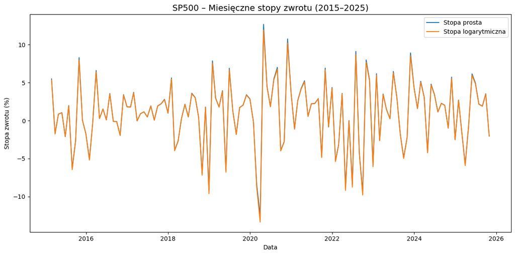

```python
# MIESIĘCZNE
returns_monthly = compute_returns(data_frame_monthly["Zamkniecie"])
print(returns_monthly.tail(10))
plot_returns(returns_monthly, "SP500 – Miesięczne stopy zwrotu (2015–2025)")
```

# 4. Dla danych dziennych z lat 2022-2024 oraz miesięcznych z lat 2007-2024, narysować wykres obu typów stóp zwrotu oraz wykres różnicy między stopą prostą i logarytmiczną. Jakie wnioski wynikają z obserwacji (proszę o 1-2 zdania wyjaśnienia)?

```python
# Funckja pomocnicza to rysowania wykresu różnicy stóp
def plot_difference(df, title):
    diff = df['Prosta'] - df['Logarytmiczna']
    fig, ax = plt.subplots(figsize=(12,4))
    ax.plot(df.index, diff, color='orange')
    ax.set_title(title, fontsize=14)
    ax.set_xlabel('Data')
    ax.set_ylabel('Różnica (p.p.)')
    plt.tight_layout()
    plt.show()
```

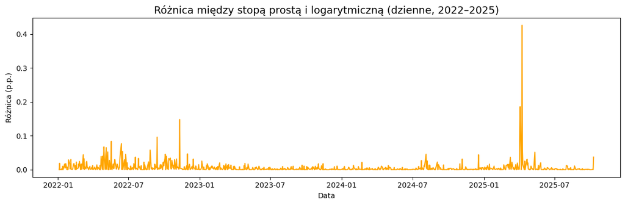

[figure not shown]

```python
data_daily_period = data_frame_daily.loc['2022-01-01':'2025-12-31']
returns_daily = compute_returns(data_daily_period['Zamkniecie'])

data_monthly_period = data_frame_monthly.loc['2007-01-01':'2025-12-31']
returns_monthly = compute_returns(data_monthly_period['Zamkniecie'])

plot_difference(returns_daily, "Różnica między stopą prostą i logarytmiczną (dzienne, 2022–2025)")
plot_difference(returns_monthly, "Różnica między stopą prostą i logarytmiczną (miesięczne, 2007–2025)")
```

# Wnioski

Analizując na początku wykresy na, których mamy zwroty proste i logarytmowane widzimy, że różnica jest 'praktycznie zerowa', ale właśnie prawie, że zerowo.

Dla małych zmian indeksu rożnice między stopami są mniejsze, niż, gdy zmiany indeksu są większe. Dlatego dla danych dziennych (gdzie zmiany są bardzo małe) obie stopy są często bardzo podobne.

Przy większych zmianach, zaczyna być widoczna mocniej różnica, która ukazuje nam, że przy większych zmianach prosta stopa zwrotu jest większa niż logarytmiczna.